# lab6

```python
import numpy as np
import matplotlib
import matplotlib.pyplot as plt
import scipy
import random
import statistics
from scipy import stats
```

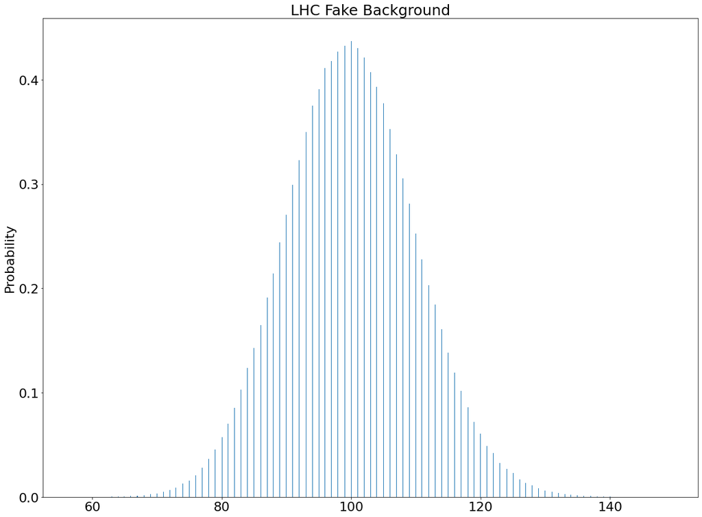

```python
plt.rcParams["figure.figsize"] = (20,15)
mean = 100
LHCPO = stats.poisson.rvs(mean, size = 1000000)
plt.hist(LHCPO, 1000,density=True)
plt.title("LHC Fake Background",fontsize=25)
plt.ylabel('Probability')
plt.show()
```

problem 1

```python
threshold = stats.poisson.ppf(1-1/(3.5*pow(10,6)),100)
print("Five sigma threshold is: " + str(threshold))
```

```
Five sigma threshold is: 154.0
```

problem 2

a) I pick 350 to be the signal

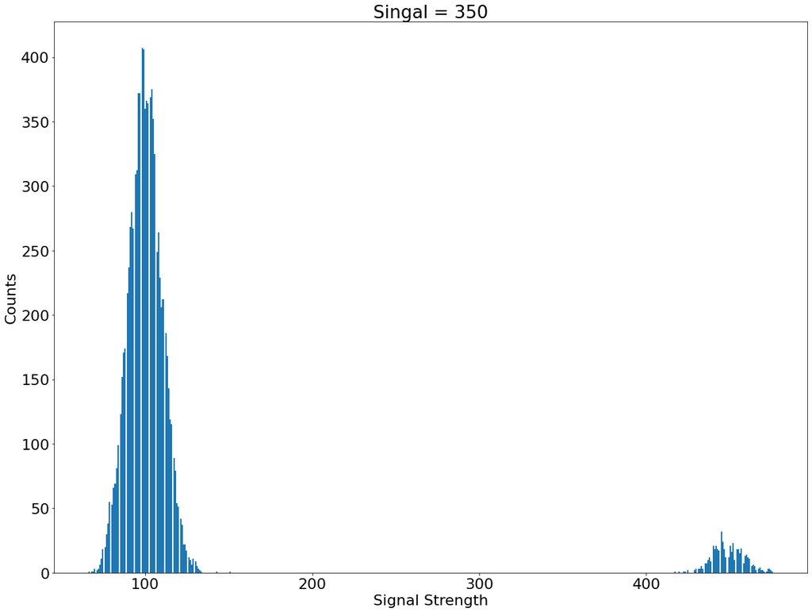

```python
inject = np.zeros(10000)
inject[random.sample(range(1,10000),500)] = 350
signal =  np.random.poisson(100,10000) + inject
fig, ax = plt.subplots()
ax.hist(signal,bins=500)
ax.set_title("Singal = 350")
ax.set_xlabel("Signal Strength")
ax.set_ylabel("Counts");
```

means locate at 100 and 450

The left part of the histogram has a remarkably gaussian shape.This histogram tells us there is some random background following a relatively gaussian distribution centered around 100. Due to the visible signal is the real observed signal, which has a mean around 450, and the injected signal is 350. And the noise has a mean around 100, so the observed signal is biased.

b)

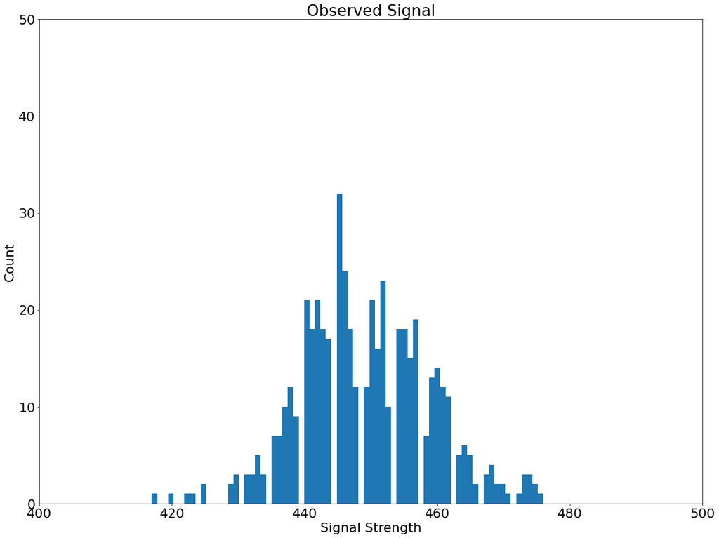

```python
fig, ax = plt.subplots()
ax.hist(signal,bins=500)
ax.set_xlim((400,500))
ax.set_ylim((0,50))
ax.set_title("Observed Signal")
ax.set_xlabel("Signal Strength")
ax.set_ylabel("Count");
```

I set the signal to 350, as a result, I observe a stronger signal that its mean is around 450. The histogram is not exactly symmetric, but nearly has a symmetric shape.

problem 3

a

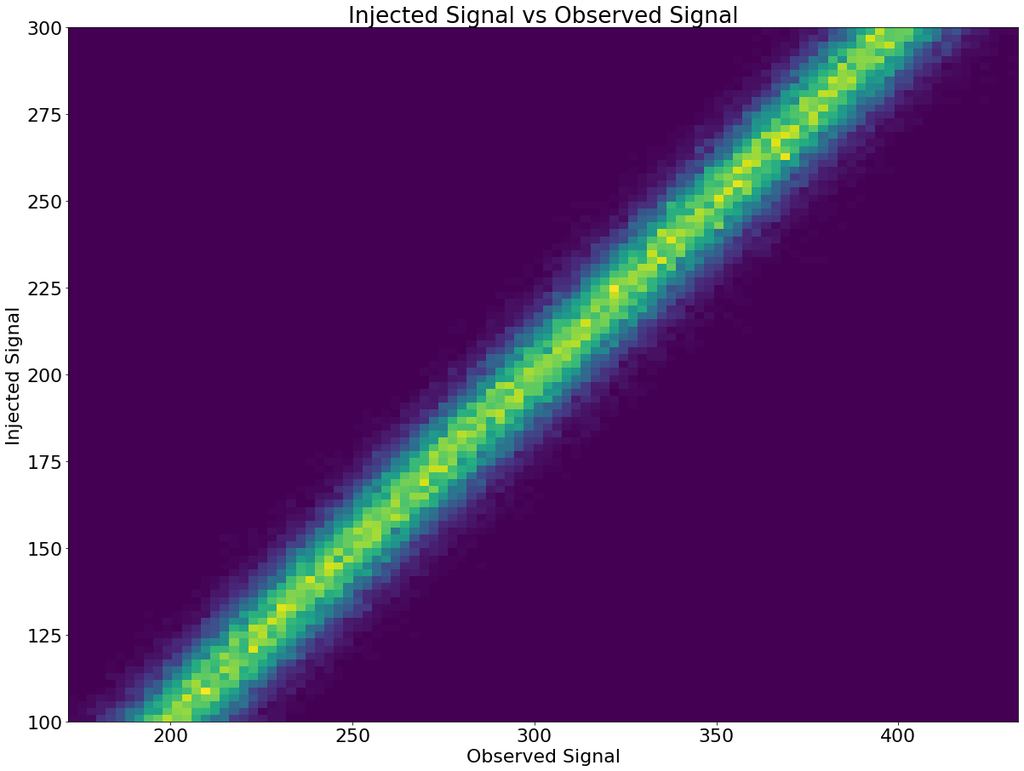

```python
size = 100000
mu = 100
noise = stats.poisson.rvs(mu = mu, size=size)
injection = np.linspace(100,300,size)
observed = noise + injection
plt.hist2d(observed, injection, 100)
plt.ylabel("Injected Signal")
plt.xlabel("Observed Signal")
plt.title("Injected Signal vs Observed Signal")
plt.show()
```

so we can tell that two signals comerge at around 200

b

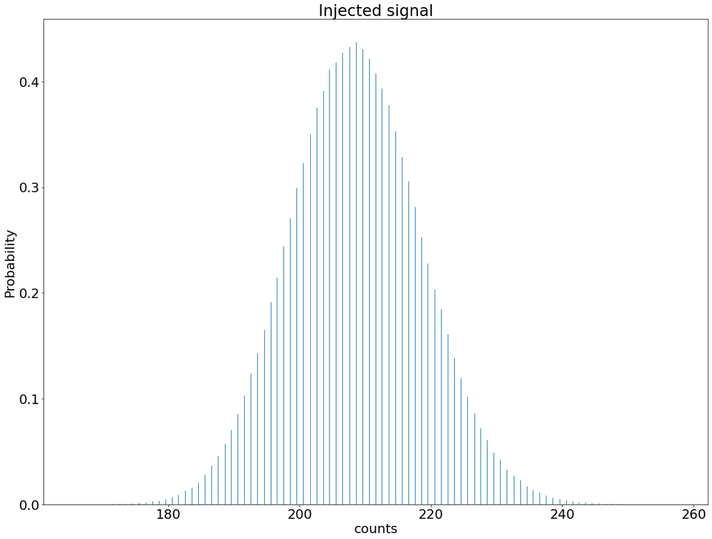

```python
resiginal = LHCPO + injection [4300]
fx, ax = plt.subplots(1, 1)
ax.hist(resiginal, 1000,density=True)
ax.set_title('Injected signal')
ax.set_xlabel( 'counts')
ax.set_ylabel('Probability')
```

the histogram looks just like what I got in former problem

c

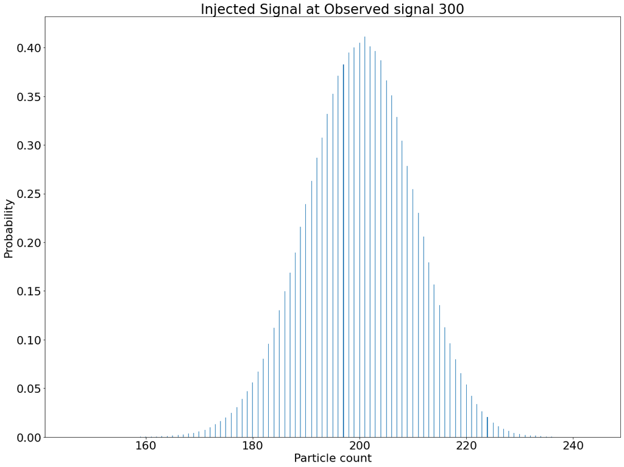

```python
observedsignal = 300
noise = stats.poisson.rvs(mu=100, size=1000000)
observed = np.ones(1000000)*observedsignal
injection = observed - noise
h = plt.hist(injection, bins=1000, density=True)
plt.title('Injected Signal at Observed signal 300')
plt.xlabel('Particle count')
plt.ylabel('Probability')
plt.show()
```

The graph above shows the probability distribution of injected signal with an observed signal of 300. As we can see that under the observed signal of 300, the mean of injected signal is about 200 which is consistant with the 2D histogram.

d

```python
mean = injection.mean()
std = injection.std()
upbound = stats.norm.isf(stats.norm.sf(1), loc=mean, scale=std)
lobound = stats.norm.isf(stats.norm.cdf(1), loc=mean, scale=std)
print('lower bound : ' + str(lobound))
print('upper bound : ' + str(upbound))
```

```
lower bound : 190.01155335184592
upper bound : 210.00077064815406
```

e

Our injection signal looks normal and symmetric. It is biased since the true injected signal is about 190 - 210 while the observed signal is way much higher than that as the signal set to 300.